# Homework 2 writeups

**Name:** Oorjit Chowdhary

**Section:** AMATH 301 B

### Problem 1

```python
import numpy as np

# Coding Problem 2
## Part a
y1, y2, y3, y4 = 0, 0, 0, 0
term1, term2, term3, term4 = 0.1, 0.1, 0.25, 0.5

for k in range(100000):
    y1 += term1

for k in range(100000000):
    y2 += term2

for k in range(100000000):
    y3 += term3

for k in range(100000000):
    y4 += term4

## Part b
x1 = np.abs(10000 - y1)
x2 = np.abs(y2 - 10000000)
x3 = np.abs(25000000 - y3)
x4 = np.abs(y4 - 50000000)

print(x1, x2, x3, x4)
```

```
1.8848368199542165e-08 0.018870549276471138 0.0 0.0
```

##### Part (a)

In Problem 2 of the coding portion of the homework, I found the following values for $x_1, x_2, x_3,$ and $x_4$.

| $x_1$ | $x_2$ | $x_3$ | $x_4$ |
| --- | --- | --- | --- |
| 1.8848368199542165e-08 | 0.018870549276471138 | 0.0 | 0.0 |

Ranking from smallest to largest, we get: $$x_3 = x_4 < x_1 < x_2$$

##### Part (b)

But these values also contain two outliers, $x_3$ and $x_4$, as they are exactly zero while they were also derived from floating point numbers algebra. I think the reason for this the choice of numbers used for `term3` and `term4` as they can be considered as multiples of 2, which makes it easier for the compiler.

##### Part (c)

Going ahead with the information given in the hint, `term3 = 0.25` can be represented as $2^{-2}$ and `term4 = 0.5` can be represented as $2^{-1}$. As the numbers are perfectly contained in base 2 notation, there will **NOT** be any truncation error. Hence $x_3$ and $x_4$ are exactly zero.

### Problem 2

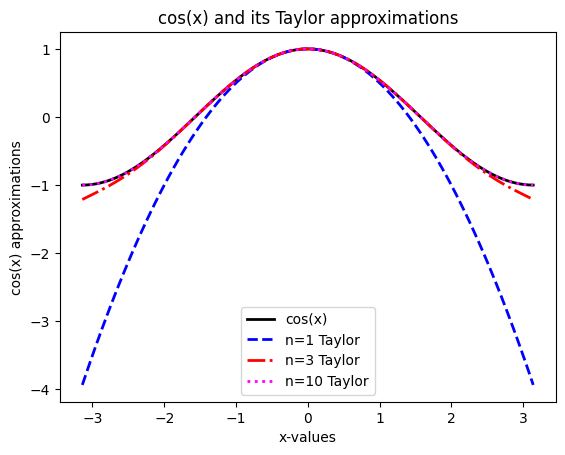

```python
import numpy as np
import matplotlib.pyplot as plt

x = np.linspace(-np.pi, np.pi, 100)
y = np.cos(x)
taylor_n1, taylor_n3, taylor_n10 = 0 * x, 0 * x, 0 * x

for k in range(2):
    taylor_n1 += (-1) ** k * x ** (2 * k) / np.math.factorial(2 * k)

for k in range(4):
    taylor_n3 += (-1) ** k * x ** (2 * k) / np.math.factorial(2 * k)

for k in range(11):
    taylor_n10 += (-1) ** k * x ** (2 * k) / np.math.factorial(2 * k)

plt.plot(x, y, color='k', linewidth=2)
plt.plot(x, taylor_n1, color='b', linewidth=2, linestyle='--')
plt.plot(x, taylor_n3, color='r', linewidth=2, linestyle='-.')
plt.plot(x, taylor_n10, color='magenta', linewidth=2, linestyle=':')
plt.legend(['cos(x)', 'n=1 Taylor', 'n=3 Taylor', 'n=10 Taylor'])

plt.xlabel('x-values')
plt.ylabel('cos(x) approximations')
plt.title('cos(x) and its Taylor approximations')
```